# Incarceration Trends in America

Beliz Ozhan

2022-11-21

## Abstract

Tracking incarceration across America by state, gender, race, and more we can use data analysis to identify trends in the data and social issues related to the demographic of prison populations. The importance of this research is highlighted through this report which includes key data summary values and charts that show patterns of inequality geographically, racially, and yearly.

## Introduction

Mass incarceration is a growing problem globally, but especially in the United States. Through data analysis it is evident that the majority of people incarcerated are immigrants, people of color, or those from a poorer demographic. The second principle of Data Feminism is to challenge “unequal power structures and work toward justice” (Ko 1). Vera embodies this principle of Data Feminism as it is an organization which aims to fight systemic injustices in the criminal legal system and reduce the amount of those suffering prison punishment and police brutality.

Specifically, for this data research there are many indirect and direct stakeholders that engage the central values of fighting to end prison population inequality. Direct stakeholders related to incarceration trends include prisoners, prison wardens and faculty, and government officials working around the process of incarceration. Indirect stakeholders are data analysts and activists fighting to end inequities in prison population distribution.

This report summarizes key values regarding which racial groups are incarcerated most across America. The growth of prison populations both nationally and by state. The trends over time of the prevalence of certain racial groups in jail. And a map visualizing the total degree to which Native people are being incarcerated by state across the United States.

## Data Summary

Across America certain racial groups occupy higher percentages of prison populations out of others in different states. Looking at which racial groups are most incarcerated in which states is important to understand the patterns of inequality in the prison system. The state with the highest population of Black prisoners from 1970 to 2018 is NY. For Latinx prisoners and AAPI prisoners the highest populations were respectively, CA and CA. And for Native prisoners from 1970 to 2018 the state with the highest population was OK. What these data values show us is that to a large extent, concentration of a racial groups in jail relates to the amount of minority populations in a state. Specifically, the larger the minority population in that area the greater the likelihood that the minority group will be subject to the oppressive incarceration system. Additionally, in this time frame the state with the highest total population of White prisoners was CA. This connects back to the idea of population density, as well as the the idea that more the prevalence of a minority race in an area, the more likely they will be subject to the prison system.

## Growth of the U.S. Prison Population

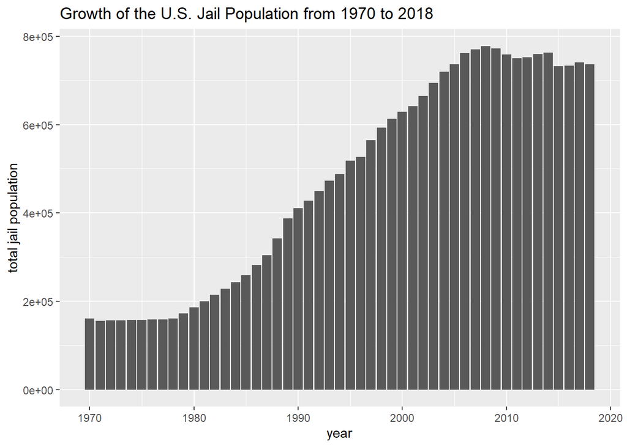

*The growth of United States jail populations from 1970 to 2018 from jurisdiction level data.*

What is the general trend of United States jail populations from 1970 to 2018? The bar chart shows a general increase of total jail population in the United States for those years. This increase in jail population increased steadily from about 1980 to 2010, when after the total jail population steadied.

## Growth of Jail Population by State

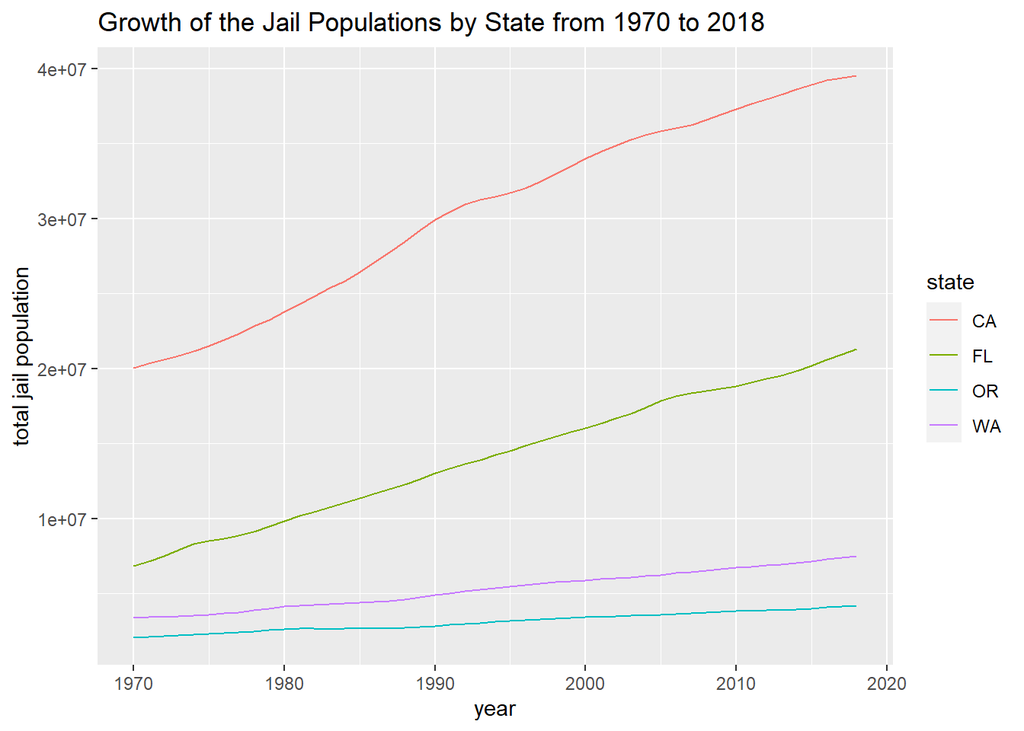

*The growth of United States jail populations by selected states from 1970 to 2018.*

How does the population of a state compare to the total growth of jail population for that state? This line chart depicts that the total jail population of a state is largely correlational to the population of the state itself. For example, out of the selected states, California has the greatest overall population, thus consequently has the highest total jail population over the years.

## Race Comparison of Jail Populations

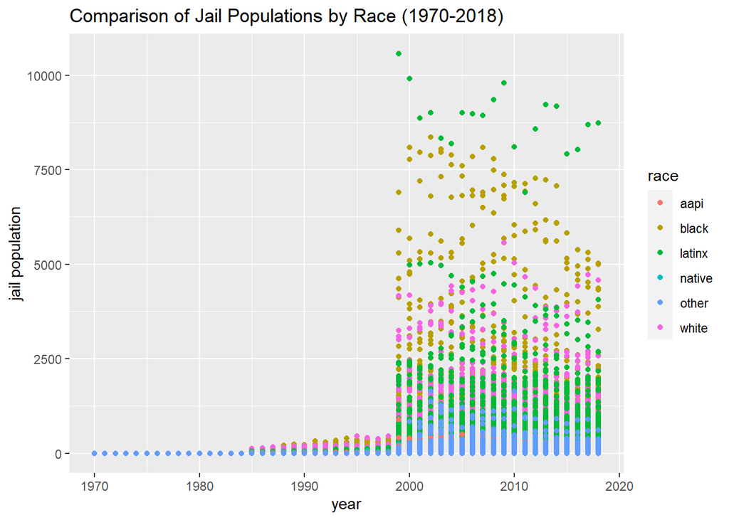

*Comparison of jail populations by racial groups from the years 1970 to 2018 across the United States.*

## Map of Native Incarceration Rates by State

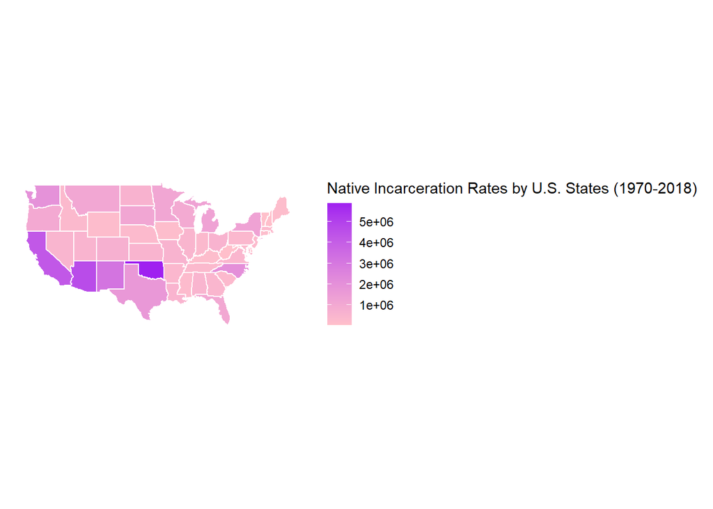

*Map of the United States showing the total jail populations of Natives across different states between 1970 to 2018.*

In what states do the most Native people get incarcerated? States with the highest Native incarcerated population include Oklahoma, California, and Arizona. In general the largest population of Indigenous peoples in jail are in the Southwestern states of America. This is partly because states such as Oklahoma and California have some of the largest numbers of tribes and reservations in America. This geographical distribution shows that many Natives are subject to the oppressive and unequal prison system, even though they make up a small percentage of said states total populations.